# Westmark Loyalty Account Analysis

BYU-Idaho Westmark Project Team

### The Data

```r
# run profit calculation function on the data
Profit <- profit_calculation(history_2023, loyalty_2023, checking_2021)

normalized_profit <- normalize_profit(history_2023, Profit)
```

The following is an initial overview of the data provided by Westmark. In order to assure proper analysis and maintain sense of standardization, `.csv` file data as cleaned, values correct, and separated into properly updated variables.

#### Age Groups

The graph shows the number of accounts by age group, alongside the percentage of those with or without a Rewards account. Notable points:

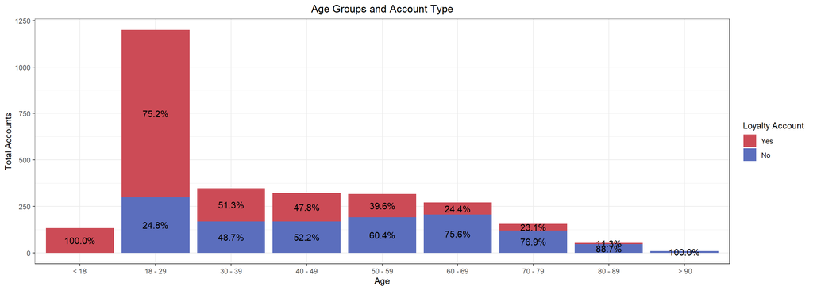

```r
Profit$Age_Group <- factor(
  Profit$Age_Group,
  levels = c("< 18" ,"18 - 29","30 - 39","40 - 49","50 - 59",
             "60 - 69","70 - 79","80 - 89"," > 90"  ))

ch_age <- Profit |>
  group_by(Age_Group, Rewards) |>
  filter(Age > 16 & Age < 100) |>
  summarise(total = n()) |>
  mutate(pct= prop.table(total) * 100)

# Graph.
ggplot(ch_age, aes(x = Age_Group, y = total, fill = Rewards)) +
  geom_bar(stat = "identity") +
  geom_text(aes(label=paste0(sprintf("%1.1f", pct),"%")),
            position=position_stack(vjust=0.5), size = 4) +
  labs(title = "Age Groups and Account Type",
       x = "Age",
       y = "Total Accounts",
       fill = "Loyalty Account") +
  scale_fill_manual(labels=c("Yes", "No"), values=c("#cc4b56", "#5b6ebd")) +
  theme_bw() +
  theme(
        plot.title = element_text(hjust = 0.5))
```

#### Branches

The following graph shows the number of accounts by **Branch Number** and **Loyalty Account** status. Notable Points:

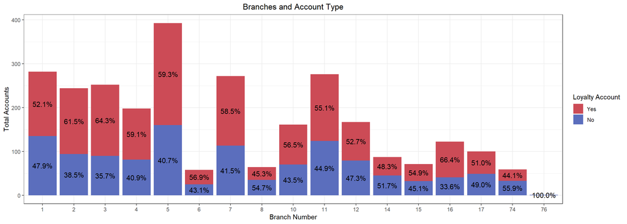

```r
products <- other_products %>%
  mutate(CD = case_when(CD == 0 ~"No",CD >= 1 ~ "Yes"),
         Auto = case_when(Auto == 0 ~"No",Auto >= 1 ~ "Yes"),
         RealEstate = case_when(RealEstate == 0 ~"No",RealEstate >= 1 ~ "Yes"),
         MoneyMarket = case_when(MoneyMarket == 0 ~"No",MoneyMarket >= 1 ~ "Yes"),
         SecondarySaving = case_when(SecondarySaving == 0 ~"No",SecondarySaving >= 1 ~ "Yes"),
         VEHL = case_when(VEHL == 0 ~"No",VEHL >= 1 ~ "Yes")) %>%
  pivot_longer(!ukey, names_to = "products") %>%
  left_join(Profit, by = "ukey")
```

#### Other Products

The following graph shows the **Other Products** and the `Reward` status makeup per category. Notable points:

- Most of the product types have an almost equal percentage distribution across the board, `Money Market` being the exception.
- `Money Market` loan customers stand apart by having 12% Loyalty Account make up, as well as the least amount of customers.
- `Secondary Savings` and `Auto Loans` are the most popular **Other Products**.

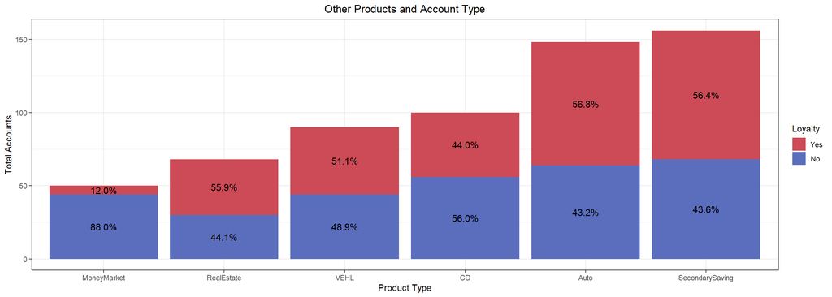

### Income

#### Age Group

The following graph shows the amount of income brought in from total fees per customer by age group. Notable points:

- Overall, `Loyalty Account` holders bring in more income than those with regular banking accounts.
- `Loyalty Accounts` have a much wider range than Regular Accounts do.

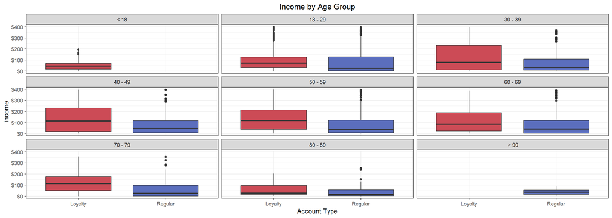

#### Branches

The following graph compares income between branches and the type of account. Notable points:

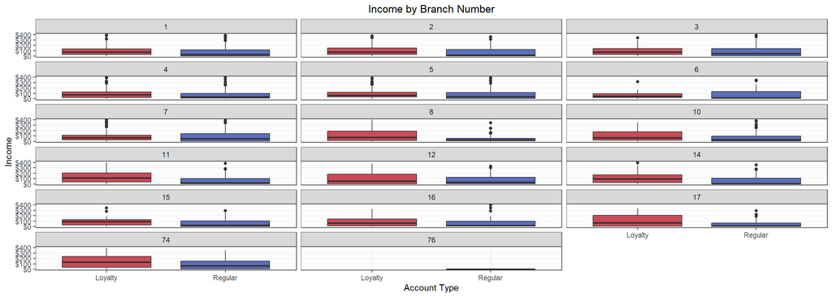

### Rewards Redeemed

#### Age Group

The visual below shows the amount of rewards redeemed by age group. Notable points:

- We can see that the amount of rewards redeemed seems to create an arch across the age groups, peaking at `50-59`.
- Younger groups, although having the highset `Loyalty Account` make up, redeem the least compared to their peers.

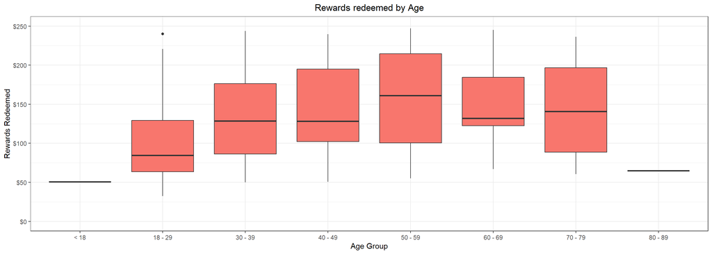

#### Branches

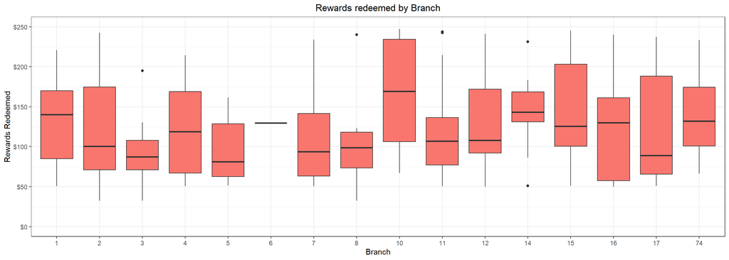

### Profit

#### Age Groups

The visual below compares profit by age group, which results from calculating the income and subtracting any redeemed rewards. Notable points:

- Overall the median profit of `Loyalty Accounts` are higher than that of Regular Checking account holders.
- We do have multiple `Loyalty Accounts` that are negative and therefore a loss.

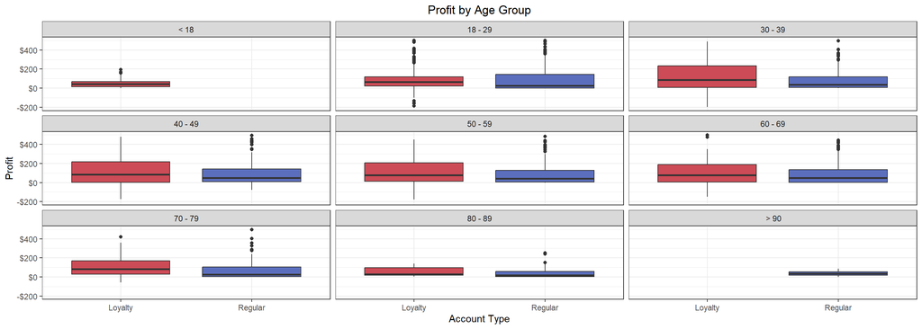

#### Branches

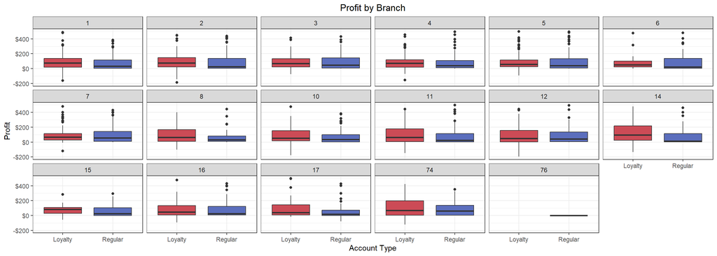

### Normalized Profit

In 2023, Westmark updated the time frame in which people can accumulate points, decreasing from three to two years. Because of this change in policy, we could see a lot of values in the data that were negatively affected. To normalize this, we calculated the amount of points they would’ve earned in the 2023 period and subtracted it from the amount of rewards people redeemed that year. The visuals below represent that adjustment:

- We can see that the median spending for each age group is noticeably *higher* on the loyalty accounts, except for the **90+** age group.
- The difference is increasingly noticeable in users from age *30-60.*

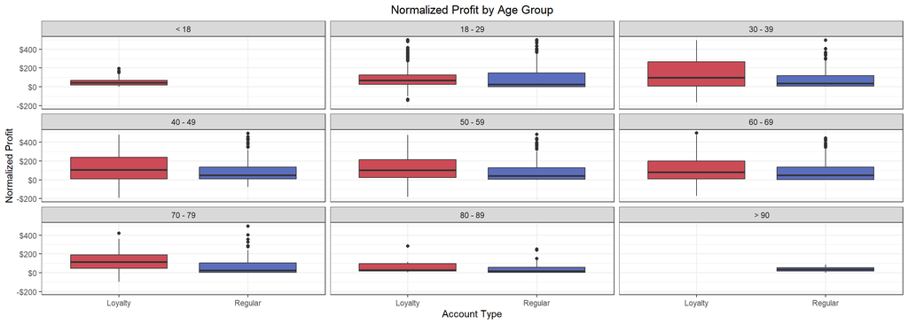

#### Branches

We can see across the board that `Loyalty Accounts` have a higher median looking at each individual branch, with the exception of `Branch 6`. This is a positive sign as it shows that generally `Loyalty Accounts` bring in more profit.

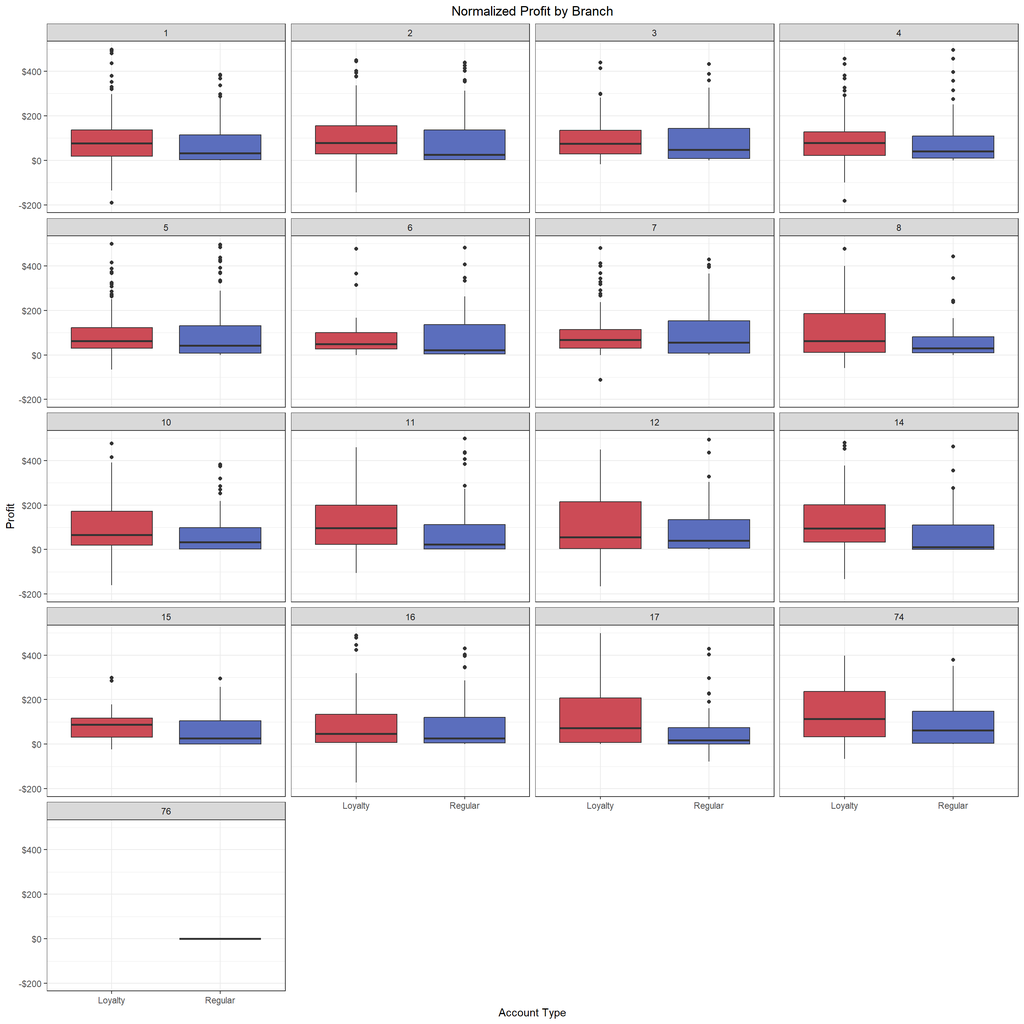

#### Median Profit Comparison

The summary provided aids in visualizing the findings mentioned above.

```r
datatable(normalized_profit %>%
  group_by(Age_Group, Rewards) %>%
  summarise(Median = round(median(normalized_profit),2)) %>%
  pivot_wider(names_from = Rewards, values_from = Median) %>%
  replace_na(replace = list(Regular = 0, Loyalty = 0)) %>%
  mutate(Difference = round(Loyalty - Regular,2)) %>%
  inner_join(normalized_profit %>% group_by(Age_Group) %>% summarise(Count = n()), by = "Age_Group"))
```

|  | Age_Group | Loyalty | Regular | Difference | Count |
| --- | --- | --- | --- | --- | --- |
| 1 | &lt; 18 | 44.46 | 0 | 44.46 | 133 |
| 2 | 18 - 29 | 70.19 | 41.18 | 29.01 | 1196 |
| 3 | 30 - 39 | 147.9 | 40.66 | 107.24 | 346 |
| 4 | 40 - 49 | 172.39 | 49.68 | 122.71 | 321 |
| 5 | 50 - 59 | 121.57 | 44.22 | 77.35 | 315 |
| 6 | 60 - 69 | 82.18 | 49.35 | 32.83 | 271 |
| 7 | 70 - 79 | 116.42 | 25.47 | 90.95 | 156 |
| 8 | 80 - 89 | 27.48 | 16.27 | 11.21 | 53 |
| 9 | &gt; 90 | 0 | 35.95 | -35.95 | 9 |

```r
datatable(normalized_profit %>%
  group_by(BranchNumber, Rewards) %>%
  summarise(Median = round(median(normalized_profit),2)) %>%
  pivot_wider(names_from = Rewards, values_from = Median) %>%
  replace_na(replace = list(Regular = 0, Loyalty = 0)) %>%
  mutate(Difference = round(Loyalty - Regular,2)) %>%
  inner_join(normalized_profit %>% group_by(BranchNumber) %>% summarise(Count = n()), by = "BranchNumber"))
```

|  | BranchNumber | Loyalty | Regular | Difference | Count |
| --- | --- | --- | --- | --- | --- |
| 1 | 1 | 79.2 | 40.73 | 38.47 | 281 |
| 2 | 2 | 83.72 | 40.66 | 43.06 | 243 |
| 3 | 3 | 77.14 | 50.24 | 26.9 | 252 |
| 4 | 4 | 78.07 | 43.76 | 34.31 | 197 |
| 5 | 5 | 64.31 | 44.64 | 19.67 | 393 |
| 6 | 6 | 49.16 | 67.14 | -17.98 | 58 |
| 7 | 7 | 69.57 | 59.89 | 9.68 | 270 |
| 8 | 8 | 71.7 | 31.18 | 40.52 | 64 |
| 9 | 10 | 75.51 | 36.03 | 39.48 | 161 |
| 10 | 11 | 100.26 | 23.69 | 76.57 | 276 |

[output cut: 7 more lines]

#### Mean Profit Differences

Upon comparing the means naturally, there’s a variance in the numbers shown. The biggest difference seems to be in the `18-29` age group, as they are largest group in the data. The assumption would be there are specific individuals or subgroups in that age group that are skewing the averages.

```r
datatable(normalized_profit %>%
  group_by(Age_Group, Rewards) %>%
  summarise(Mean = round(mean(normalized_profit),2)) %>%
  pivot_wider(names_from = Rewards, values_from = Mean) %>%
  replace_na(replace = list(Regular = 0, Loyalty = 0)) %>%
  mutate(Difference = round(Loyalty - Regular,2)) %>%
  inner_join(normalized_profit %>% group_by(Age_Group) %>% summarise(Count = n()), by = "Age_Group"))
```

|  | Age_Group | Loyalty | Regular | Difference | Count |
| --- | --- | --- | --- | --- | --- |
| 1 | &lt; 18 | 49.89 | 0 | 49.89 | 133 |
| 2 | 18 - 29 | 98.74 | 180.29 | -81.55 | 1196 |
| 3 | 30 - 39 | 216.52 | 99.89 | 116.63 | 346 |
| 4 | 40 - 49 | 226.23 | 119.07 | 107.16 | 321 |
| 5 | 50 - 59 | 177.95 | 111.07 | 66.88 | 315 |
| 6 | 60 - 69 | 120.6 | 99.59 | 21.01 | 271 |
| 7 | 70 - 79 | 137.04 | 68.96 | 68.08 | 156 |
| 8 | 80 - 89 | 78.65 | 44.53 | 34.12 | 53 |
| 9 | &gt; 90 | 0 | 39.79 | -39.79 | 9 |

Most of the branches below seem to show a positive difference, which again, is a good sign.

```r
datatable(normalized_profit %>%
  group_by(BranchNumber, Rewards) %>%
  summarise(Mean = round(mean(normalized_profit),2)) %>%
  pivot_wider(names_from = Rewards, values_from = Mean) %>%
  replace_na(replace = list(Regular = 0, Loyalty = 0)) %>%
  mutate(Difference = round(Loyalty - Regular,2)) %>%
  inner_join(normalized_profit %>% group_by(BranchNumber) %>% summarise(Count = n()), by = "BranchNumber"))
```

|  | BranchNumber | Loyalty | Regular | Difference | Count |
| --- | --- | --- | --- | --- | --- |
| 1 | 1 | 146.92 | 116.57 | 30.35 | 281 |
| 2 | 2 | 122.75 | 143.01 | -20.26 | 243 |
| 3 | 3 | 114.85 | 112.88 | 1.97 | 252 |
| 4 | 4 | 109.09 | 95.33 | 13.76 | 197 |
| 5 | 5 | 105.71 | 123.07 | -17.36 | 393 |
| 6 | 6 | 87.81 | 162.86 | -75.05 | 58 |
| 7 | 7 | 103.44 | 134.39 | -30.95 | 270 |
| 8 | 8 | 204.62 | 119.8 | 84.82 | 64 |
| 9 | 10 | 123.19 | 89.77 | 33.42 | 161 |
| 10 | 11 | 149.91 | 96.9 | 53.01 | 276 |

[output cut: 7 more lines]

### Other Products

#### Products and Profit

When we look at how the different loan types for the data, we can see that it’s generally in favor of the `Loyalty Accounts` in terms of profits, with the exception of CD loans.

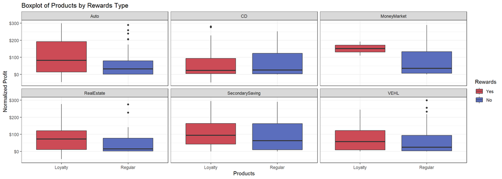

```r
products <- other_products %>%
  mutate(CD = case_when(CD == 0 ~"No",CD >= 1 ~ "Yes"),
         Auto = case_when(Auto == 0 ~"No",Auto >= 1 ~ "Yes"),
         RealEstate = case_when(RealEstate == 0 ~"No",RealEstate >= 1 ~ "Yes"),
         MoneyMarket = case_when(MoneyMarket == 0 ~"No",MoneyMarket >= 1 ~ "Yes"),
         SecondarySaving = case_when(SecondarySaving == 0 ~"No",SecondarySaving >= 1 ~ "Yes"),
         VEHL = case_when(VEHL == 0 ~"No",VEHL >= 1 ~ "Yes")) %>%
  pivot_longer(!ukey, names_to = "products") %>%
  left_join(normalized_profit, by = "ukey") %>%
  drop_na() %>%
  filter(value == "Yes")

# Graph.
ggplot(products)+
  aes(x = Rewards, y = normalized_profit, fill = Rewards)+
  geom_boxplot() +
  scale_fill_manual(labels=c("Yes", "No"), values=c("#cc4b56", "#5b6ebd")) +
  facet_wrap(~products)+
  labs(title = "Boxplot of Products by Rewards Type", x = "Products", y = "Normalized Profit", fill = "Rewards") +
  theme_bw() +
   scale_y_continuous(limit = c(-50, 300), labels=scales::dollar_format())
```

Below shows the loan accounts by *profit* and *age group*.

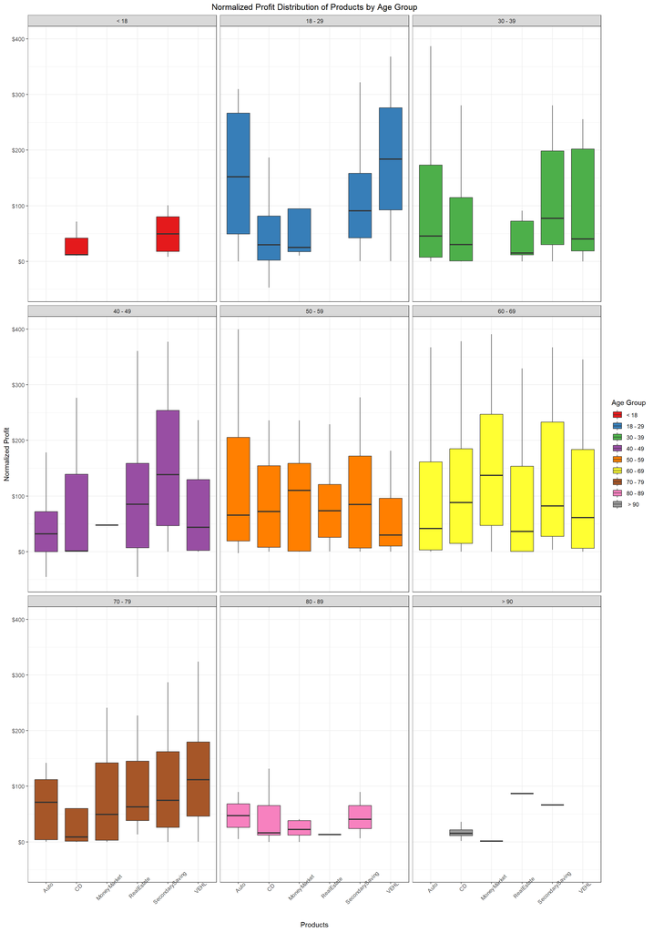

```r
ggplot(products, aes(x = products, y = normalized_profit, fill = Age_Group)) +
  geom_boxplot(outlier.shape = NA) +
  labs(title = "Normalized Profit Distribution of Products by Age Group", x = "Products", y = "Normalized Profit", fill = "Age Group") +
  theme_bw() +
  theme(
        plot.title = element_text(hjust = 0.5),
        plot.subtitle = element_text(hjust = 0.5),
        axis.text.x = element_text(angle = 45)) +
  facet_wrap(~ Age_Group, ncol = 3) +
  scale_fill_brewer(palette = "Set1") +
  scale_y_continuous(limit = c(-50, 400),  labels=scales::dollar_format())
```

### Confidence Intervals

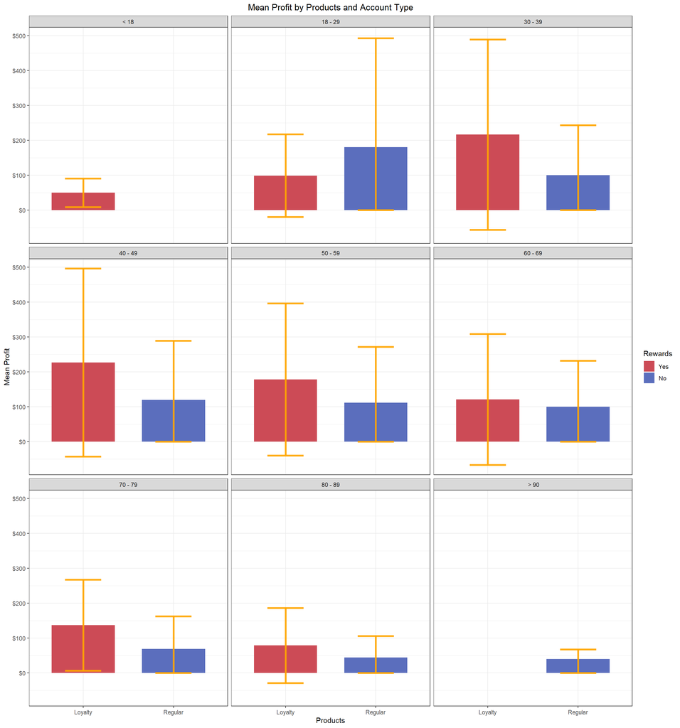